# Comments for MEDB 5502, Week 03

## Topics to be covered

- What you will learn
  - What is covariate imbalance?
  - Indicator variable coding
  - Mathematical model
  - Assumptions

## What is a covariate?

- Variable not of direct interest
  - Relationship to outcome is already established
  - Still must be accounted for
- Examples
  - Smoking in a cancer study
  - Gestational in a neonatology study
- A covariate can be continuous or categorical

## What is covariate imbalance?

- Difference in mean value between treatment and control group
  - Often a problem in observational studies
  - Sometimes a problem in randomized studies

## Why is covariate imbalance an issue?

- Biased estimates
  - Comparing apples to oranges
- Harms study credibility

## Examples of covariate imbalance

- Age in a study of smoking and Down’s syndrome
- Smoking in a study of artillery assignment and sperm count

## Covariate imbalance versus confounding

- Covariate imbalance is simpler
- Confounder definition relies on causation arguments

## Preventing covariate imbalance

- Randomization
- Matching
- Stratification

## Adjusting for covariate imbalance

- Propensity score models
- Analysis of covariance

## Variables cannot be in the causal pathway

- Fixed at time of randomization
- Temporally preceding exposure
- Example: bottles given during a breast feeding study

## Adjusting for baseline measurements

- Baseline = measurements prior to intervention
  - Done to improve precision
  - Can use baseline as a covariate
- Change score is an alternative
  - Also known as difference in differences (DID) model
  - Possible regression to the mean

## Break #1

- What you have learned
  - What is covariate imbalance?
- What’s coming next
  - Indicator variable coding

## Traditional t-test, 1 of 4

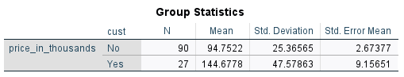

## Traditional t-test, 2 of 4

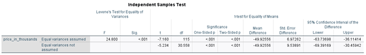

## Traditional t-test, 3 of 4

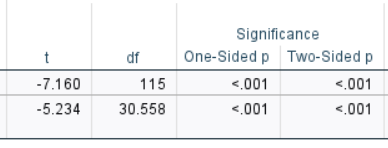

## Traditional t-test, 4 of 4

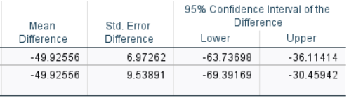

## T-test using general linear model

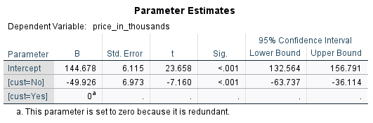

## Indicator variable coding

- Convert binary categories
  - 1 for “first” category
  - 0 for “second” category
    - Choice of “first” is arbitrary
- Can also be used for three or more categories

## T-test using indicator variable

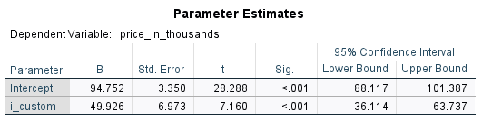

## Why use the general linear model?

- Works for a variety of models
  - Independent samples t-test
  - Simple linear regression
  - One factor analysis of variance
  - Multiple linear regression
  - Analysis of covariance
  - Multi-factor analysis of variance

## Why use indicator variables

- Simple interpretation
  - Average indicator is a probability
- Mix categorical and continuous independent variables

## Live demo, Indicator variable coding

## Break #2

- What you have learned
  - Indicator variable coding
- What’s coming next
  - Mathematical model

## Mathematical model

- $Y_i=\beta_0+\beta_1 X_i+\beta_2 T_i+\epsilon_i$
  - $X_i$ is the covariate
  - $T_i$ is an indicator variable for treatment
- Estimate $\hat\beta_0,\ \hat\beta_1,\ \hat\beta_2$

## Interpretation, 1 of 4

- $\hat\beta_0$
  - estimated average value of Y
    - when X=0, T=0

## Interpretation, 2 of 4

- $\hat\beta_1$
  - estimated average change in Y
    - when X increases by one unit and
    - T is held constant

## Interpretation, 3 of 4

- $\hat\beta_2$
  - estimated average change in Y
  - when T increases by one unit and
  - X is held constant

## Interpretation, 4 of 4

- $\hat\beta_0$ is intercept for controls
- $\hat\beta_0+\hat\beta_2$ is intercept for treatment

- $\hat\beta_2$ is the adjusted average difference between the treatment and the control

## Diference in price adjusted for size

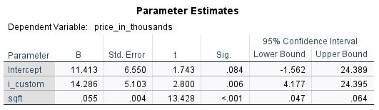

## Visualization

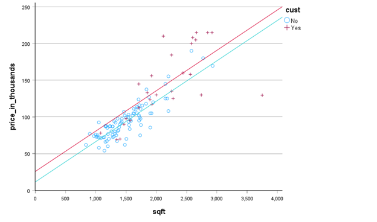

## Interpretation

- The estimated average price for a regular home with zero square feet is 11 thousand dollars.
- The adjusted average difference in price between a regular house and a custom built house holding the size of the house constant is 14 thousand dollars
- The estimated average price increases by 55 dollars when the size increases by one square foot, holding the type of house (regular or custom build) constant.
- Unadjusted
  - $11.413 + 14.286*0 + 0.055*1505.30 = 94.2045$
  - $11.413 + 14.286*1 + 0.055*2149.04 = 143.8962$
- Adjusted
  - $11.413 + 14.286*0 + 0.055*1653.85 = 102.37475$
  - $11.413 + 14.286*1 + 0.055*1653.85 = 116.66075$

## Visualization

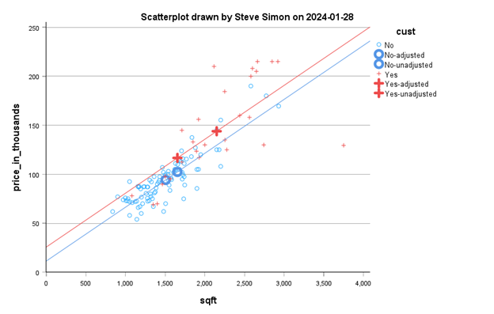

## Live demo, Mathematical model

## Break #3

- What you have learned
  - Mathematical model
- What’s coming next
  - Assumptions

## Assumptions of analysis of covariance

- Same as multiple linear regression
  - Normality
  - Equal variances
  - Linearity
- One additional assumption
  - No interaction

## Q-Q plot of residuals

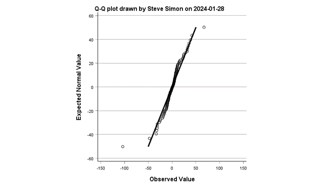

## Residuals versus predicted

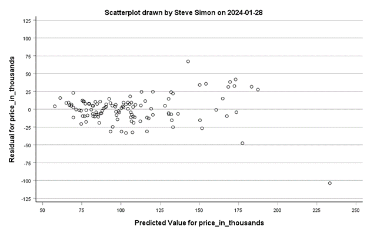

## Testing for an interaction

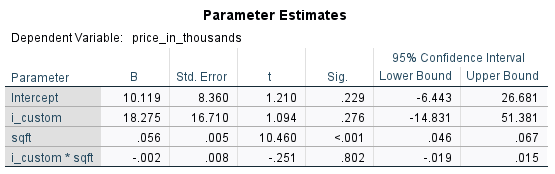

## Live demo, Assumptions

## Summary

- What you have learned
  - What is covariate imbalance?
  - Indicator variable coding
  - Mathematical model
  - Assumptions